# Using Quarto

Author

Lucas A. Meyer

Published

July 7, 2022

While I was learning [Quarto](https://www.quarto.org), I created a presentation in RevealJS to help my team learn about it.

The presentation shows how I used the same content files to generate:

- A RevealJS presentation
- A PowerPoint presentation using my team’s template
- This website (starting after the header below)
- A scholarly-looking article in PDF using LaTeX
- A scholarly-looking document using Microsoft Word

# Why Quarto

## The content value chain

Content stuck in my computer is nearly worthless.

### Goal

- Move good content out of my computer **as fast as possible**
- Reproducible
- Git-based collaboration
- Write once, generate:
  - Code
  - Paper
  - PowerPoint
  - Site/documentation

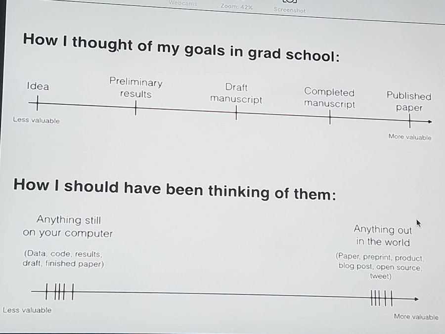

The content value chain from David Robinson’s (@drrob) Tweet

## Literate Programming

Donald E. Knuth proposed literate programming in a 1984 [article](http://www.literateprogramming.com/knuthweb.pdf).

One of my proudest tech moments was to make `CWeave` and `CWeb` (and `LaTeX`) run in a Windows computer circa 1998.

Jupyter implements the literate programming paradigm, but I haven’t seen the Markdown part gain a lot of traction.

[figure not shown]

Donald Knuth’s Literate Programming

## I tried many tools for Literate Programming

### LaTeX

- Great for PDFs… Ok, Beamer!
- Website generation is not great
- Dynamic content requires Latex programming
  - `\usepackage{ifthen}`
  - `@for`, `@while`

### Word/PPT

- Hard to collaborate before O365
- Hard to reproduce / auto-generate

### Jekyll

- Great for sites
- Not great for PPT, papers

### RMarkdown

- Great PDFs
- Mostly good presentations
- Hugo and `blogdown` work well
- Heavily dependent on R `R`

### Python notebooks

- Great, with Pandoc

# What Quarto really is

## The content pipeline for .ipynb

About [75% of data scientists](https://visualstudiomagazine.com/articles/2021/02/09/kaggle-survey.aspx) use Python through Jupyter notebooks.

With some scripting, you can use [`pandoc`](https://pandoc.org/index.html) to generate papers, HTML, PowerPoint, etc.

You just need to learn Pandoc.

```
graph LR
    A[.ipynb] --> B(("Pandoc"))
    B ----> E[.doc]
    B ----> H[.pptx]
    B --> C[.md]
    B --> D[.tex]
    D --> F((Xetex))
    C --> I((Hugo))
    F --> G[.pdf]
    I --> J[.html]
    style B fill:#FF6655AA
    style F fill:#88ffFF
    style I fill:#88ffFF
```

## Quarto in Python, in a nutshell

You can then render the outputs using `quarto render <file.qmd>` in the command line.

```
graph LR
Q[.qmd] --> A
subgraph Quarto
    A[.ipynb] --> B(("Pandoc"))
    B --> C[.md]
    B --> D[.tex]
    D --> F((Xetex))
    C --> I((Hugo))
    style B fill:#FF6655AA
    style F fill:#88ffFF
    style I fill:#88ffFF
end
    B ----> E[.doc]
    B ----> H[.pptx]
    F --> G[.pdf]
    I --> J[.html]
```

# Quarto basics

## The YAML front-matter

Whether you use Quarto from `.qmd`, `.ipynb`, or `.Rmd` files, you always start with a YAML front-matter file.

The YAML configuration determines what’s the output format of your document. A few popular output options are `html`, `pptx`, `docx`, and `pdf`.

**You can use a single source file to generate multiple output types.**

For example, the YAML on the right will generate a PowerPoint file and a Revealjs presentation.

```yaml
---
title: "Using Quarto for everything"
format:
    pptx:
        reference-doc: templates/template.pptx
    revealjs:
        incremental: false
        theme: pulse

author: Lucas A. Meyer
date: 2022-07-07
---
```

## Main content

### Writing the main content

Most writing in Quarto is done in [Markdown](https://quarto.org/docs/authoring/markdown-basics.html).

Quarto’s Markdown supports everything I’m used to: figures, tables, bibliography, etc.

It also supports lots of extra features, like diagrams with `mermaid` and `GraphViz` and even LaTeX equations:

$$E = mc^2$$

```markdown
### Writing the main content

Most writing in Quarto is done in [Markdown].

Quarto's Markdown supports everything I'm
used to: figures, tables, bibliography, etc.

It also supports lots of extra features, like
diagrams with `mermaid` and `GraphViz` and
even LaTeX equations:

$$
E = mc^2
$$
```

## What if I want to add code?

The best thing about Quarto is that you can use it to run any code that you would be able to run in a Python notebook.

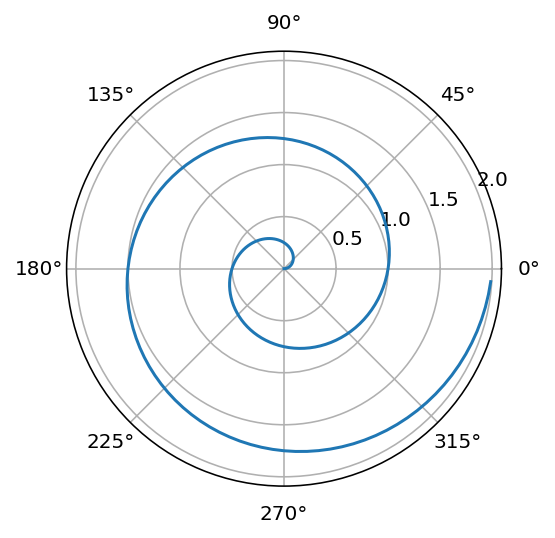

```python
import numpy as np
import matplotlib.pyplot as plt

r = np.arange(0, 2, 0.01)
theta = 2 * np.pi * r
fig, ax = plt.subplots(subplot_kw=\
                {'projection': 'polar'})
ax.plot(theta, r)
ax.set_rticks([0.5, 1, 1.5, 2])
ax.grid(True)
plt.show()
```

# Presentations in Quarto

## Basic slide syntax

To create slides, you create sections with `#`, titles with `##`, and bullets with `-`.

### Content types

- You can add several types of content
  - code (use backticks)
  - images
  - diagrams
  - tables
  - etc.

```markdown
To create slides, you create sections
with `#`, titles with `##`, and bullets
with `-`.

Quarto will render your content in slide form.

### Content types

- You can add several types of content
    - code (use backticks)
    - images
    - diagrams
    - tables
    - etc.
```

## Creating PowerPoint slides

To generate a presentation from a `.qmd` file, add `format: pptx` to the YAML front-matter.

The part I liked the *least* is that Quarto will use the [pandoc PowerPoint rules](https://pandoc.org/MANUAL.html#powerpoint-layout-choice) to render the content from the `.qmd` into the `.pptx`.

The “pandoc rules” substantially limit the flexibility you would have in PowerPoint presentations. Quarto has better presentation support for `revealjs` and `beamer`.

- Quarto can use a template with (**only**) these layouts:
  - Title Slide
  - Title and Content
  - Section Header
  - Two Content
  - Comparison
  - Content with Caption
  - Blank

## PowerPoint layout rules

The rules are available at:  
https://pandoc.org/MANUAL.html#powerpoint-layout-choice

- **Title Slide:** created from metadata fields like `title` and `author`
- **Section Header:** created from the top-level markdown headings (for example, `#`)
- **Two Content:** used when `.md` source contains `.columns` div (`:::: {.columns}`) and text content
- **Comparison:** same as “Two Content”, but content of divs is not text
- **Blank:** used for slides that have no displayable content (e.g. notes)
- **Content with Caption:** used when content doesn’t have a `columns` div but has text **and** non-text content
- **Title and Content:** whatever doesn’t fit the rules above.

## PowerPoint templates

By adding a `reference-doc` entry to your YAML, you can tell Quarto (and pandoc) to use a file as a template for the format of your presentation.

The “Slide Master” needs to contain layouts named as per the previous slide (e.g. “Comparison”).

This allows you a lot of flexibility in the design of your slide deck, even if it is for just the small number of layouts that were listed in the previous slide.

You can control fonts, add background images, page numbering, etc.

```yaml
---
title: "Using Quarto for everything"
format: pptx
reference-doc: templates/template.pptx
author: Lucas A. Meyer
date: 2022-07-14
---
```

# Dynamic content

## Best feature: generate content dynamically

Let’s say you’re presenting a project about population dynamics but you don’t know which world leaders are coming to the conference.

On the presentation day, you learn that Belgium, China, Brazil, India, Japan and Nigeria are attending.

You can use Python or R to automatically generate slides.

## Generating slides with Python

The next slides/sections were generated using the code below:

```python
df_dr = pd.read_csv("data/dr.csv.gz", compression="gzip")
df_pop = pd.read_csv("data/pop_brackets.csv.gz", compression="gzip")

years = [2000, 2025, 2050, 2075, 2100]
regions = ["Belgium", "China", "Brazil", "India", "Japan", "Nigeria"]

for name in regions:
    display(Markdown(f"## Age and Population Pyramids for {name}"))
    display(Markdown(f'<div class="columns">'))
    display(Markdown(f'<div class="column">'))
    plot_dependency_ratio(df_dr[df_dr.Location == name])
    display(Markdown(f'</div>'))
    display(Markdown(f'<div class="column">'))
    plot_population_pyramid_series(df_pop[df_pop["Location"]==name], years)
    display(Markdown(f'</div>'))
    display(Markdown(f'</div>'))
```

## Age and Population Pyramids for Belgium

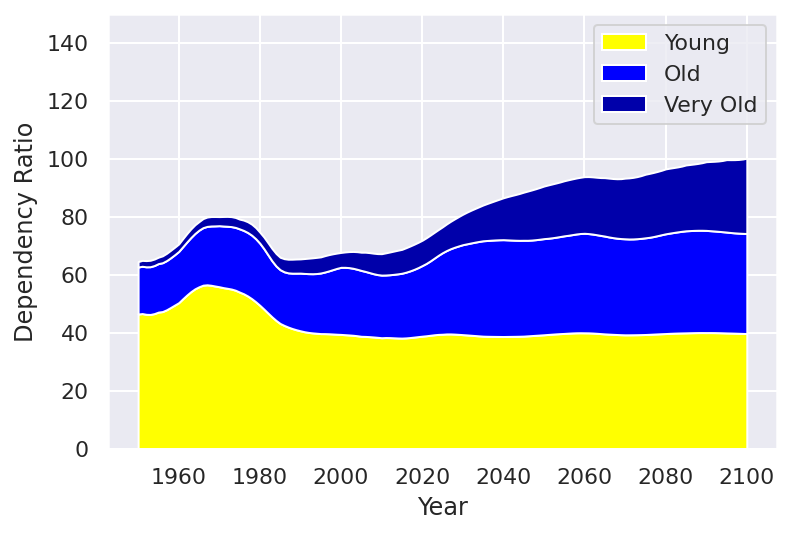

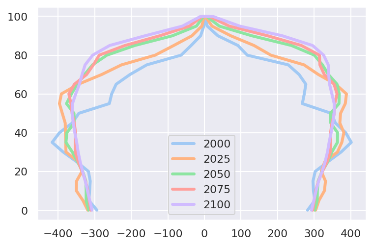

## Age and Population Pyramids for China

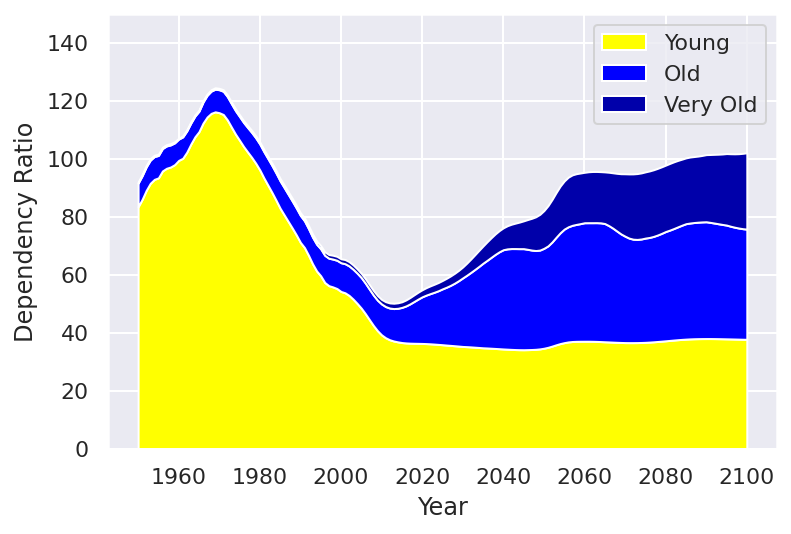

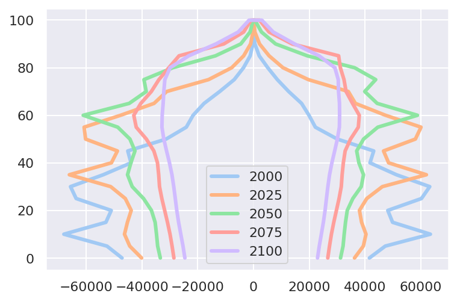

## Age and Population Pyramids for Brazil

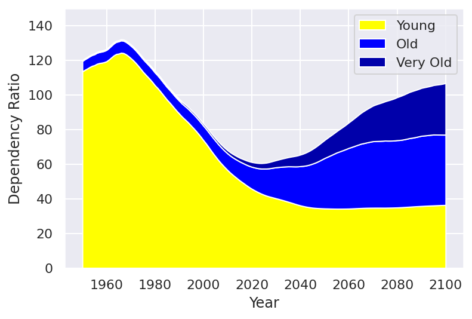

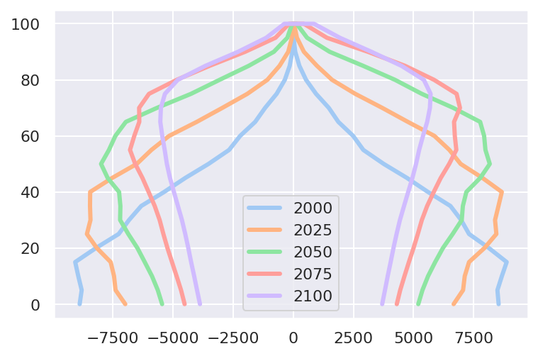

## Age and Population Pyramids for India

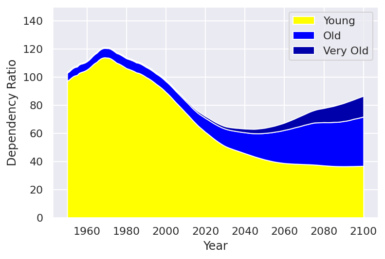

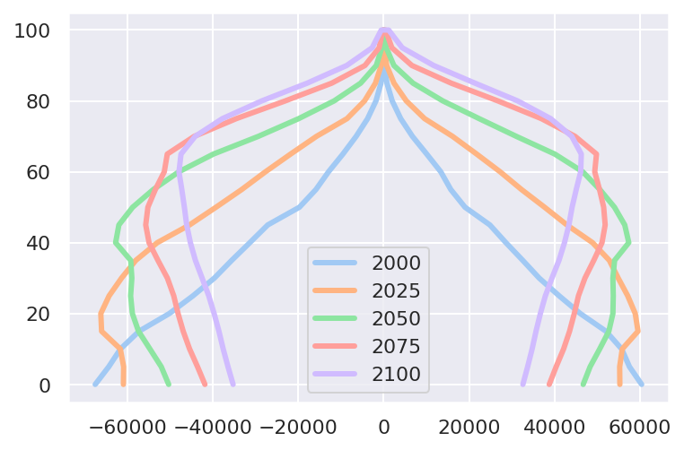

## Age and Population Pyramids for Japan

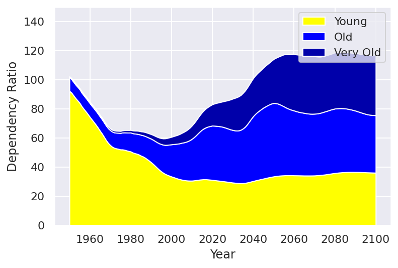

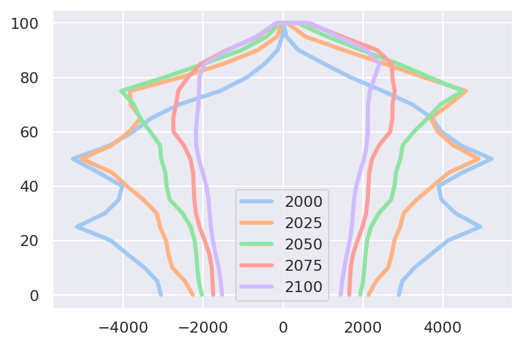

## Age and Population Pyramids for Nigeria

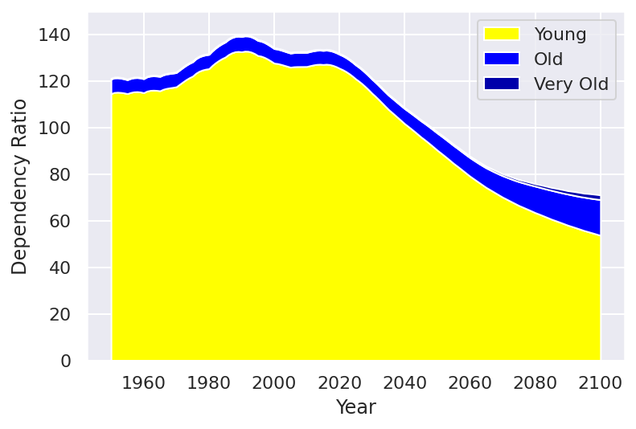

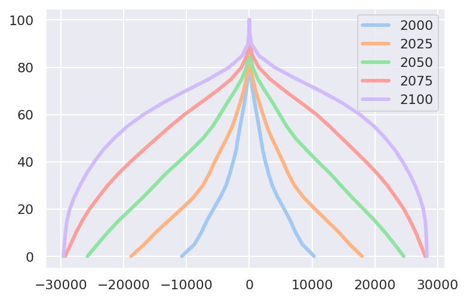

## Footnotes

[^1]: you can also add the YAML as raw content in the first cell of an .ipynb file